# Descriptive Statistics

## Normality

- A normal distribution is an arrangement of a data set in which most values cluster in the middle of the range
- A graphical representation of a normal distribution is sometimes called a *bell curve* because of its shape.
- Many procedures in statistics are based on this property. *Parametric* procedures require the normality property.
- In a normal distribution about 95% of the probability lies within 2 Standard Deviations of the mean.
- Two examples: one population with mean 60 and the standard deviation of 1, and the other with mean 60 and sd=4 (means shifted to 0)

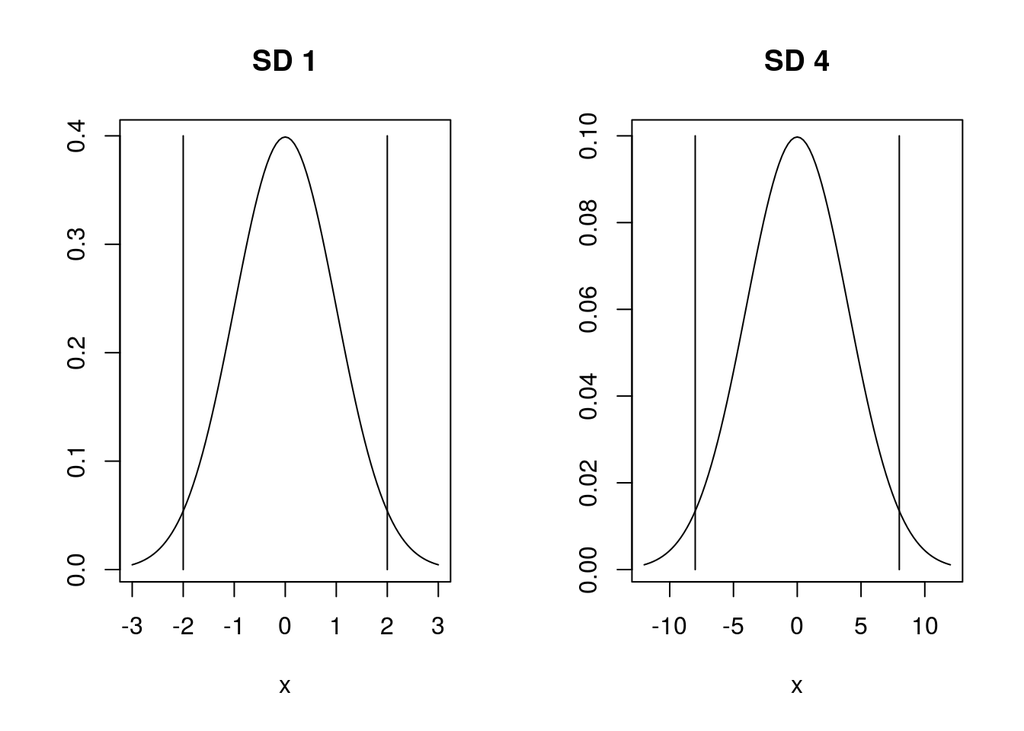

```r
main.title <- "Area within 2 SD of the mean"
par(mfrow=c(1,2))
plot(function(x) dnorm(x, mean = 0, sd = 1),
xlim = c(-3, 3), main = "SD 1", xlab = "x",
ylab = "", cex = 2)
segments(-2, 0, -2, 0.4)
segments(2, 0, 2, 0.4)
plot(function(x) dnorm(x, mean = 0, sd = 4),
xlim = c(-12, 12), main = "SD 4", xlab = "x",
ylab = "", cex = 2)
segments(-8, 0, -8, 0.1)
segments(8, 0, 8, 0.1)
```

- if we sample from this population we get “another population”.

```r
sample.means <- rep(NA, 1000)
for (i in 1:1000) {
  sample.40 <- rnorm(40, mean = 60, sd = 4) #rnorm generates random numbers from normal distribution
  sample.means[i] <- mean(sample.40)
}
means40 <- mean(sample.means)
sd40 <- sd(sample.means)
means40
```

```
## [1] 59.98301
```

```r
sd40
```

```
## [1] 0.6329627
```

- These sample means are another “population”. The sampling distribution of the sample mean is normally distributed meaning that the “mean of a representative sample provides an estimate of the unknown population mean”.

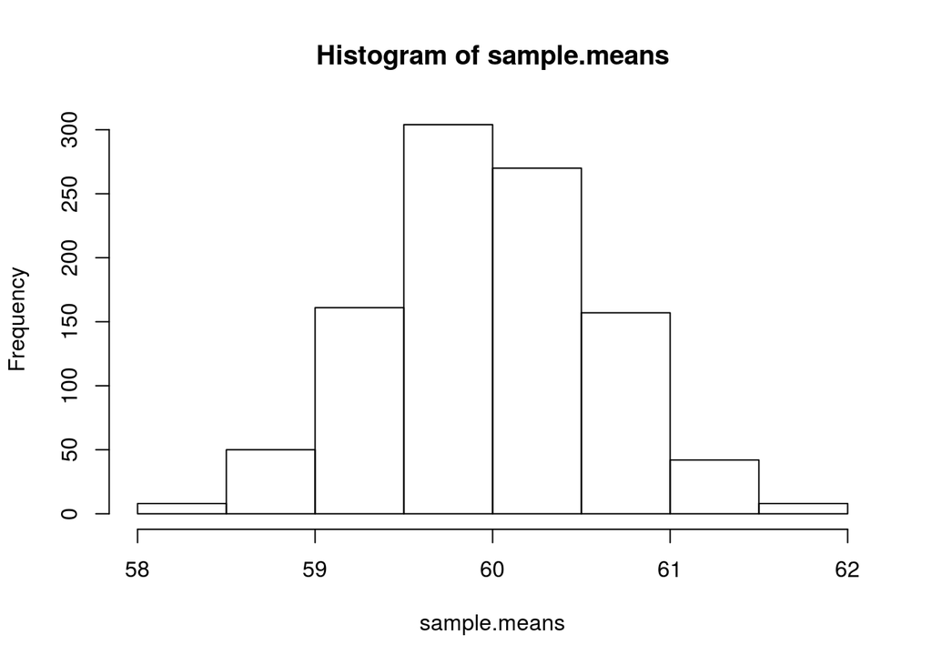

```r
hist(sample.means)
```

## Getting the Data. Descriptive statistics.

- Set the path to your files
- Read the Telecom1 dataset and print out the summary statistics with the command *summary*

```r
options(digits=3)
telecom1 <- read.table("../datasets/Telecom1.csv", sep=",",header=TRUE, stringsAsFactors=FALSE, dec = ".") #read data
summary(telecom1)
```

```
##       size           effort        EstTotal
##  Min.   :  3.0   Min.   :  24   Min.   : 30
##  1st Qu.: 37.2   1st Qu.: 119   1st Qu.:142
##  Median : 68.5   Median : 222   Median :289
##  Mean   :100.3   Mean   : 284   Mean   :320
##  3rd Qu.:164.0   3rd Qu.: 352   3rd Qu.:472
##  Max.   :284.0   Max.   :1116   Max.   :777
```

- We see that this dataset has three variables (or parameters) and few data points (18)
  - size: the independent variable
  - effort: the dependent variable
  - EstTotal: the estimates coming from an estimation method
- Basic Plots

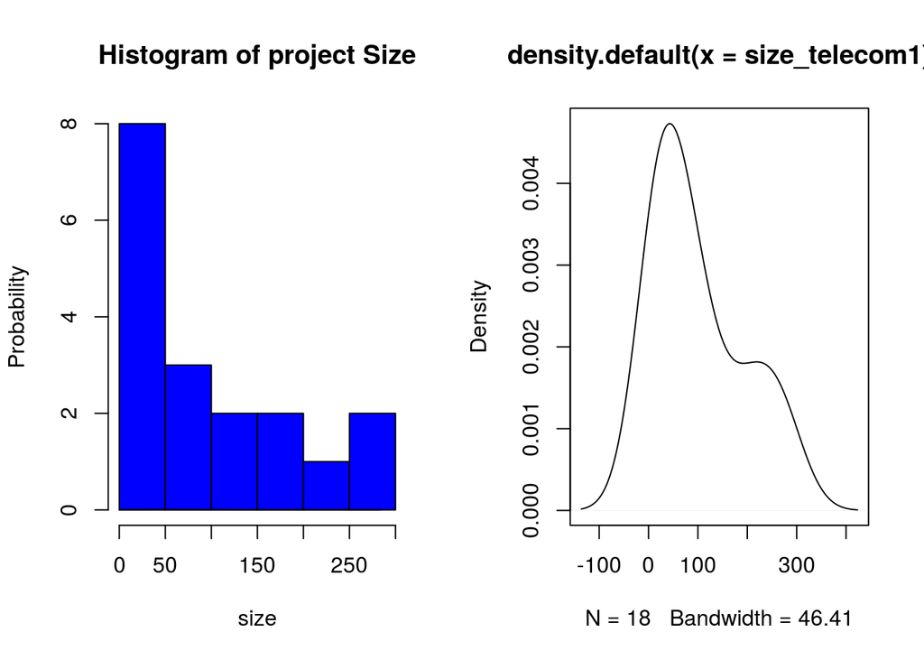

```r
par(mfrow=c(1,2)) #n figures per row
size_telecom1 <- telecom1$size
effort_telecom1 <- telecom1$effort

hist(size_telecom1, col="blue", xlab='size', ylab = 'Probability', main = 'Histogram of project Size')
lines(density(size_telecom1, na.rm = T, from = 0, to = max(size_telecom1)))
plot(density(size_telecom1))
```

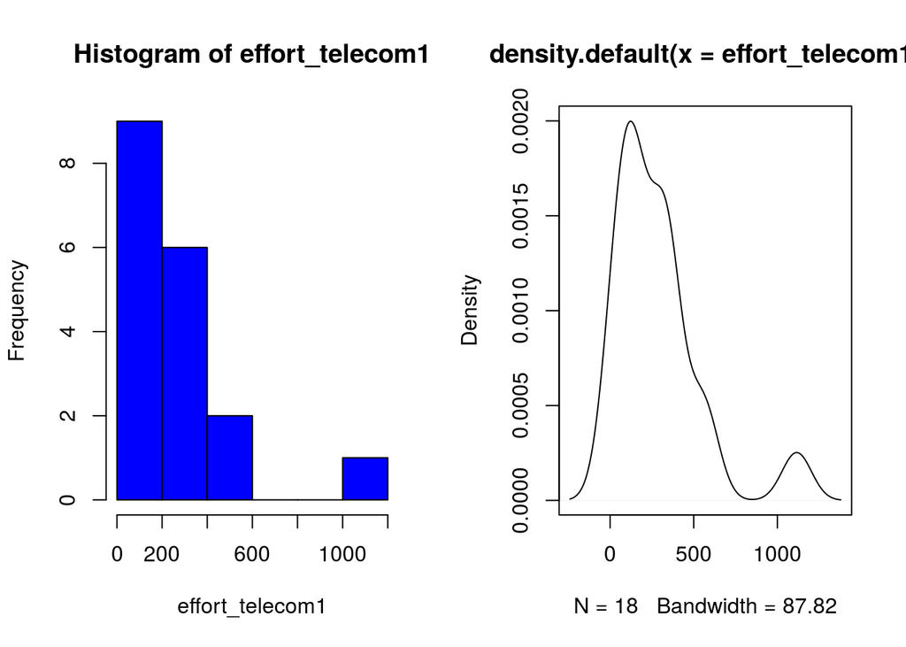

```r
hist(effort_telecom1, col="blue")
plot(density(effort_telecom1))
```

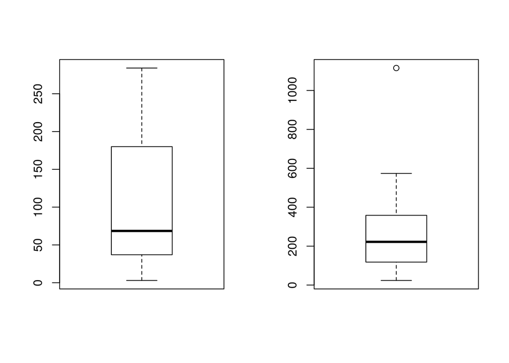

```r
boxplot(size_telecom1)
boxplot(effort_telecom1)
```

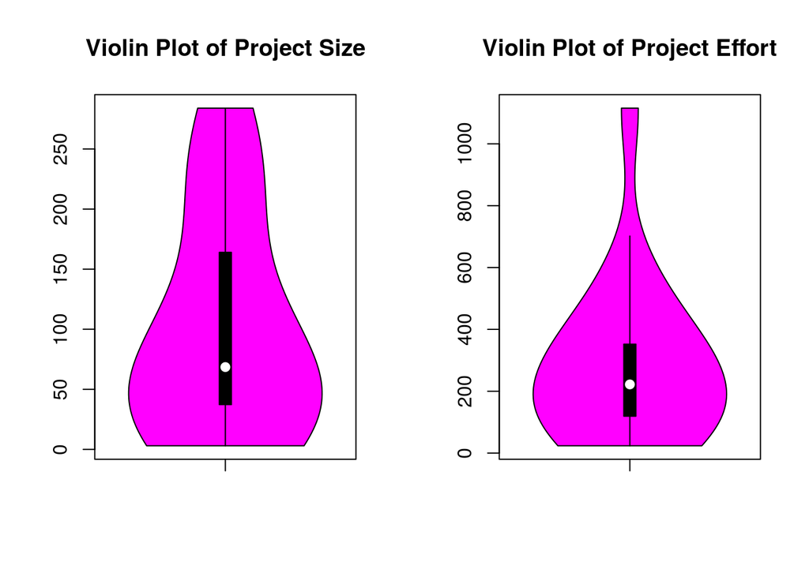

```r
# violin plots for those two variables
library(vioplot)
vioplot(size_telecom1, names = '')
title("Violin Plot of Project Size")
vioplot(effort_telecom1, names = '')
title("Violin Plot of Project Effort")
```

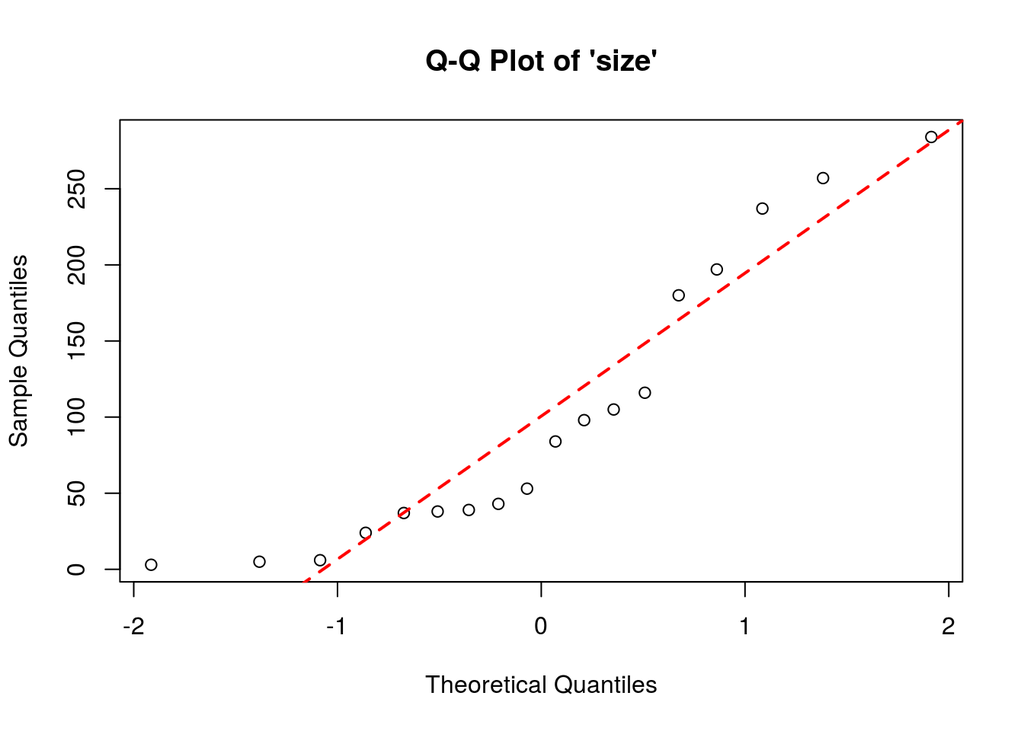

```r
par(mfrow=c(1,1))
qqnorm(size_telecom1, main="Q-Q Plot of 'size'")
qqline(size_telecom1, col=2, lwd=2, lty=2) #draws a line through the first and third quartiles
```

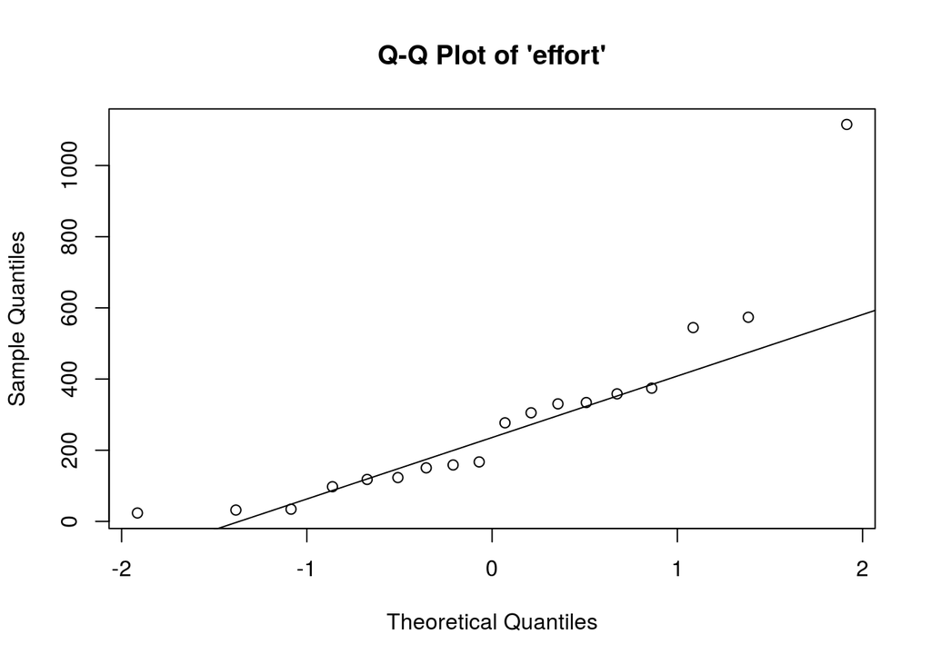

```r
qqnorm(effort_telecom1,  main="Q-Q Plot of 'effort'")
qqline(effort_telecom1)
```

- We observe the non-normality of the data.

- We may look the posible relationship between size and effort with a scatterplot

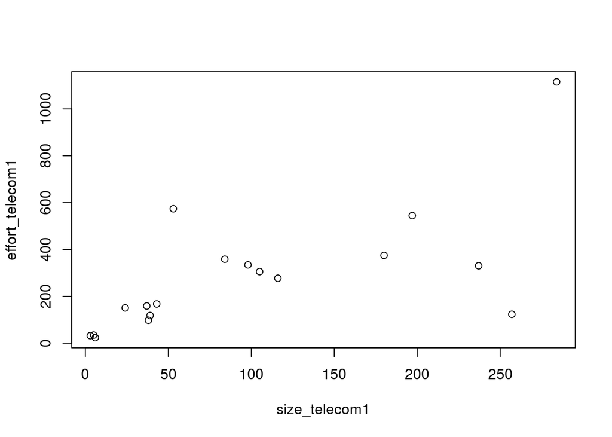

```r
plot(size_telecom1, effort_telecom1)
```

## China dataset

```r
library(foreign)
china <- read.arff("../datasets/china.arff")
china_size <- china$AFP
summary(china_size)
```

```
##    Min. 1st Qu.  Median    Mean 3rd Qu.    Max.
##       9     100     215     487     438   17500
```

```r
china_effort <- china$Effort
summary(china_effort)
```

```
##    Min. 1st Qu.  Median    Mean 3rd Qu.    Max.
##      26     704    1830    3920    3830   54600
```

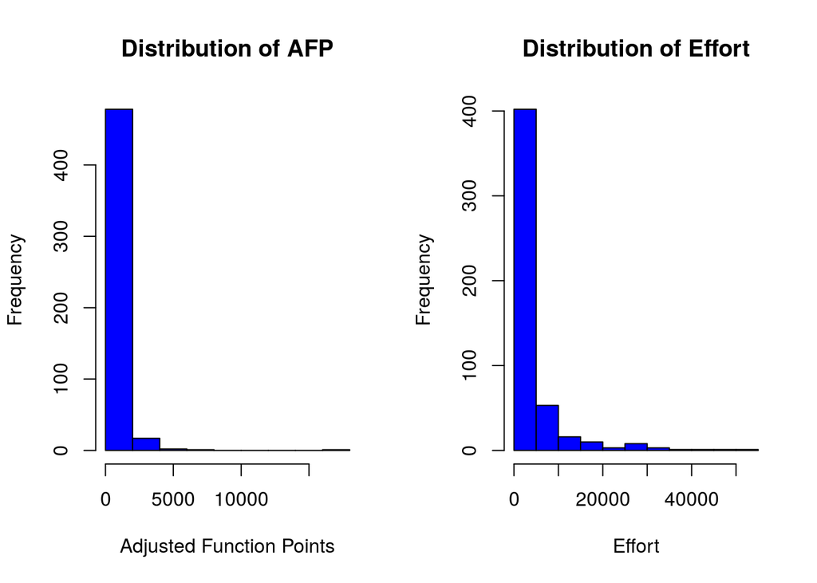

```r
par(mfrow=c(1,2))
hist(china_size, col="blue", xlab="Adjusted Function Points", main="Distribution of AFP")
hist(china_effort, col="blue",xlab="Effort", main="Distribution of Effort")
```

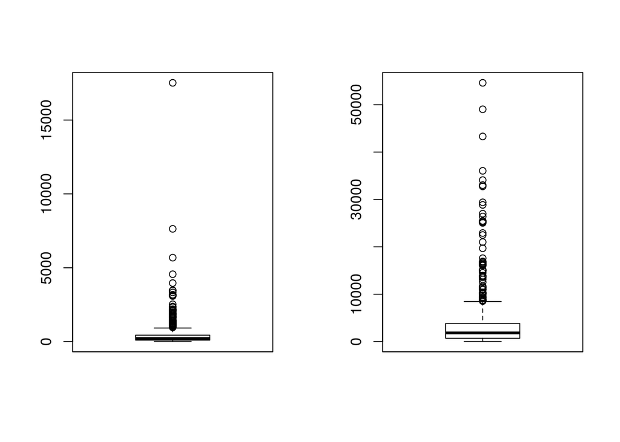

```r
boxplot(china_size)
boxplot(china_effort)
```

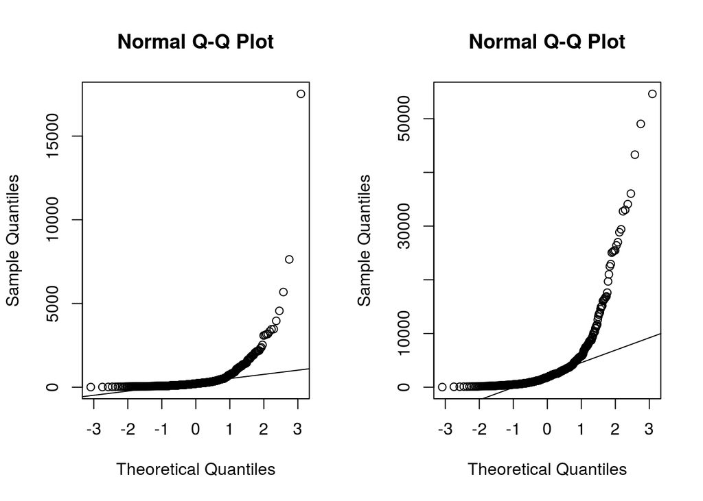

```r
qqnorm(china_size)
qqline(china_size)
qqnorm(china_effort)
qqline(china_effort)
```

- We observe the non-normality of the data.

## Normality. Galton data

- It is the data based on the famous 1885 Francis Galton’s study about the relationship between the heights of adult children and the heights of their parents.

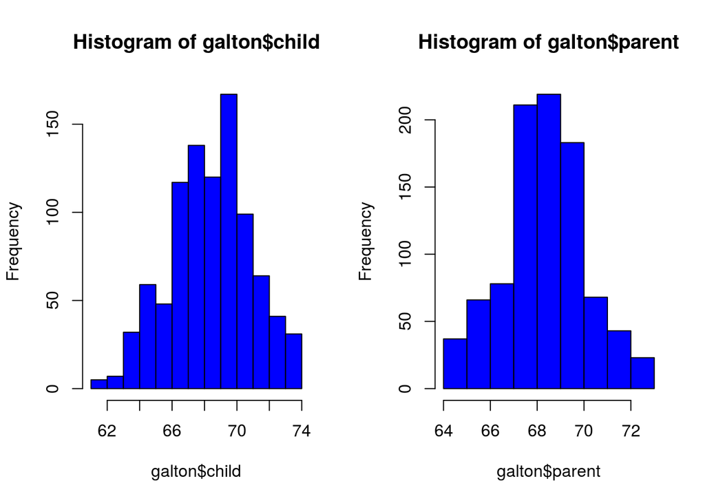

## Normalization

- China dataset. Take logs in both independent variables.

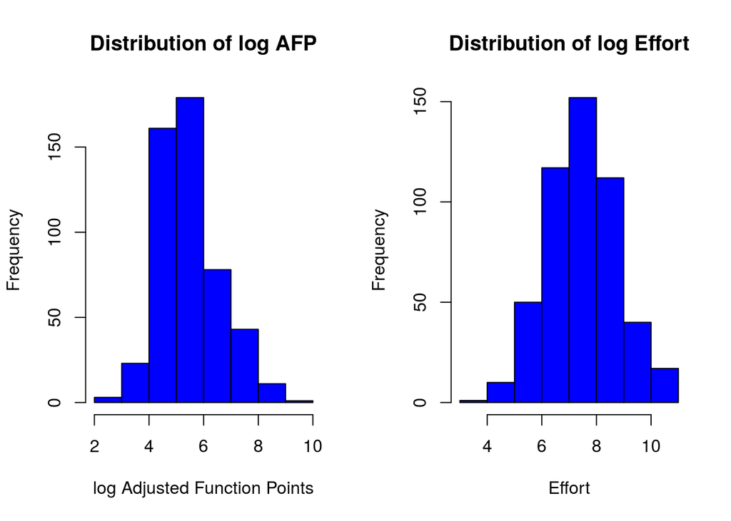

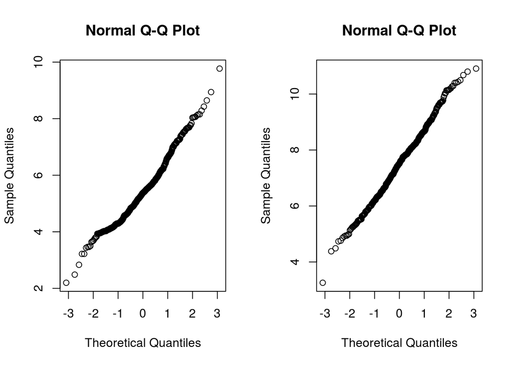

- If the log-log transformation is used the estimation equation is:

$$y= e^{b_0 + b_1 log(x)}$$

## China dataset. Correlation.

- **Correlation** is a statistical relationship between two sets of data.
- With the whole dataset we may check for the linear Correlation of the variables we are interested in.

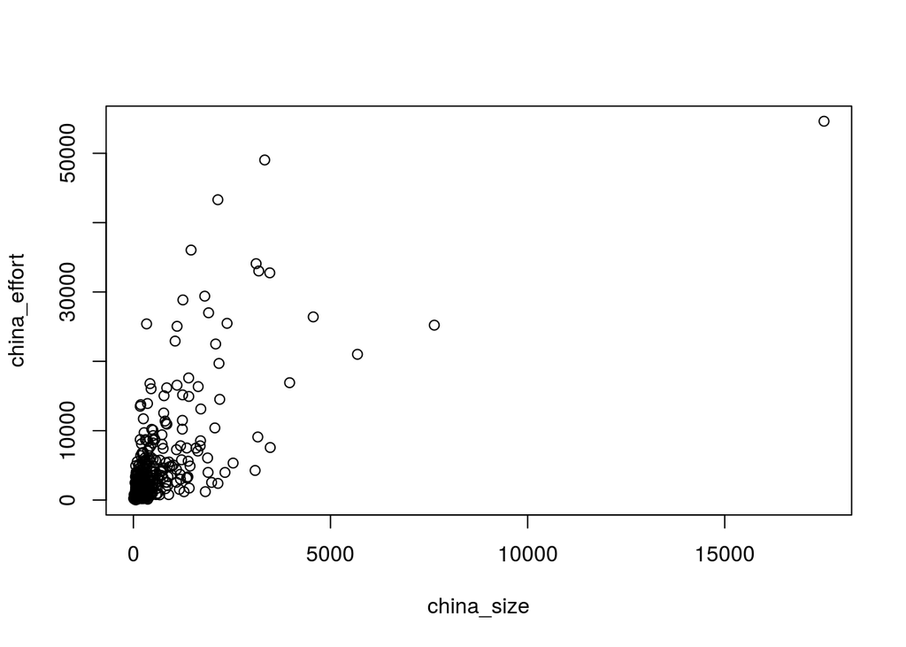

```r
par(mfrow=c(1,1))
plot(china_size,china_effort)
```

```r
cor(china_size,china_effort)
```

```
## [1] 0.685
```

```r
cor.test(china_size,china_effort)
```

```
##
##  Pearson's product-moment correlation
##
## data:  china_size and china_effort
## t = 20, df = 500, p-value <2e-16
## alternative hypothesis: true correlation is not equal to 0
## 95 percent confidence interval:
##  0.635 0.729
## sample estimates:
##   cor
## 0.685
```

```r
cor(china_size,china_effort, method="spearman")
```

```
## [1] 0.649
```

```r
cor(china_size,china_effort, method="kendall")
```

```
## [1] 0.468
```